# EDA of REd Wine Quality by KHRYSTYNE TAYLOR

## Introduction

This project aims to using R and exploratory analysis to explore the wine quality dataset which provides information of red wine. What we hope to achieve is to determine which factors contribute to the quality of wine. Esentially, what makes wine taste good and recieve higher ratings than others.

This dataset has 1599 0bservations and had 13 variables. the x column is just an index and is not needed and therefore removed

# Univariate Plots Section

```
##  [1] "fixed.acidity"        "volatile.acidity"     "citric.acid"
##  [4] "residual.sugar"       "chlorides"            "free.sulfur.dioxide"
##  [7] "total.sulfur.dioxide" "density"              "pH"
## [10] "sulphates"            "alcohol"              "quality"
```

```
## 'data.frame':    1599 obs. of  12 variables:
##  $ fixed.acidity       : num  7.4 7.8 7.8 11.2 7.4 7.4 7.9 7.3 7.8 7.5 ...
##  $ volatile.acidity    : num  0.7 0.88 0.76 0.28 0.7 0.66 0.6 0.65 0.58 0.5 ...
##  $ citric.acid         : num  0 0 0.04 0.56 0 0 0.06 0 0.02 0.36 ...
##  $ residual.sugar      : num  1.9 2.6 2.3 1.9 1.9 1.8 1.6 1.2 2 6.1 ...
##  $ chlorides           : num  0.076 0.098 0.092 0.075 0.076 0.075 0.069 0.065 0.073 0.071 ...
##  $ free.sulfur.dioxide : num  11 25 15 17 11 13 15 15 9 17 ...
##  $ total.sulfur.dioxide: num  34 67 54 60 34 40 59 21 18 102 ...
##  $ density             : num  0.998 0.997 0.997 0.998 0.998 ...
##  $ pH                  : num  3.51 3.2 3.26 3.16 3.51 3.51 3.3 3.39 3.36 3.35 ...
##  $ sulphates           : num  0.56 0.68 0.65 0.58 0.56 0.56 0.46 0.47 0.57 0.8 ...
##  $ alcohol             : num  9.4 9.8 9.8 9.8 9.4 9.4 9.4 10 9.5 10.5 ...
##  $ quality             : int  5 5 5 6 5 5 5 7 7 5 ...
```

```
##
##   3   4   5   6   7   8
##  10  53 681 638 199  18
```

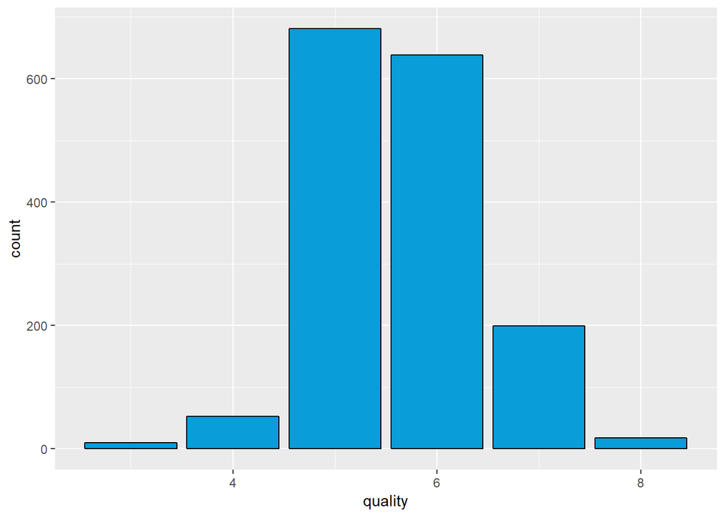

```
## [1] 213
```

```
## [1] 4.995915
```

The bar graph used to explore the quality of wines suggests that the data is normally distributed, with a mean value of 5.636. Most wines seem to be in this region and we can assume these wines are of a fairly decent quality as a quality score of 0 indicates a very poor quality wine, where a score of 10 indicates a very good quality wine.

Quality is a discrete variable and therefore geom_bar is used to best represent the data.

We will now take a closer look at the other variables that may influence the quality of wine, to establish if there is a normal distribution and to check for outliers and remove them.

A few functions were introduced to make plotting and summary of the data more efficient, also to make the code look cleaner.

```
##    Min. 1st Qu.  Median    Mean 3rd Qu.    Max.
##    4.60    7.10    7.90    8.32    9.20   15.90
##      nbr.val     nbr.null       nbr.na          min          max
## 1.599000e+03 0.000000e+00 0.000000e+00 4.600000e+00 1.590000e+01
##        range          sum       median         mean      SE.mean
## 1.130000e+01 1.330310e+04 7.900000e+00 8.319637e+00 4.354102e-02
## CI.mean.0.95          var      std.dev     coef.var
## 8.540351e-02 3.031416e+00 1.741096e+00 2.092755e-01
## [1] 144
```

```
## [1] 8.268597
```

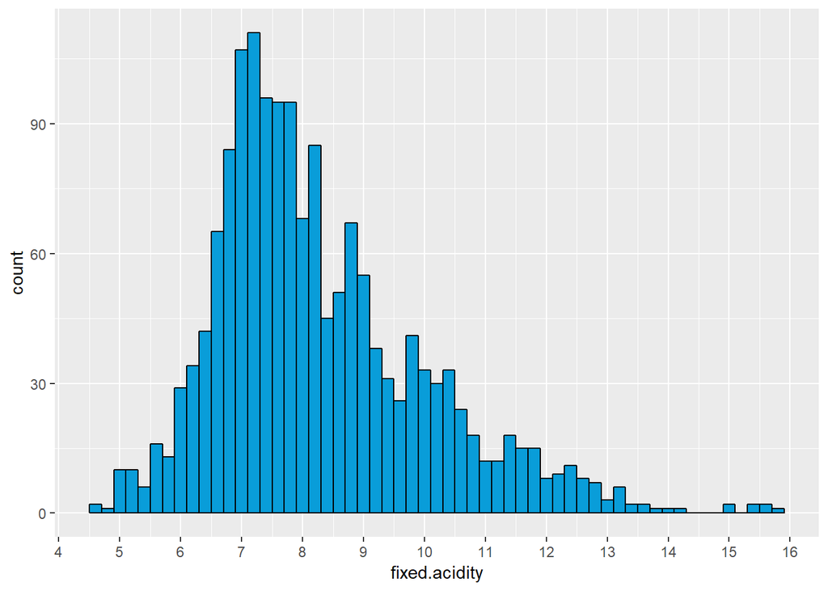

```
##    Min. 1st Qu.  Median    Mean 3rd Qu.    Max.
##  0.1200  0.3900  0.5200  0.5278  0.6400  1.5800
##      nbr.val     nbr.null       nbr.na          min          max
## 1.599000e+03 0.000000e+00 0.000000e+00 1.200000e-01 1.580000e+00
##        range          sum       median         mean      SE.mean
## 1.460000e+00 8.439850e+02 5.200000e-01 5.278205e-01 4.477892e-03
## CI.mean.0.95          var      std.dev     coef.var
## 8.783160e-03 3.206238e-02 1.790597e-01 3.392435e-01
## [1] 178
```

```
## [1] 0.5917462
```

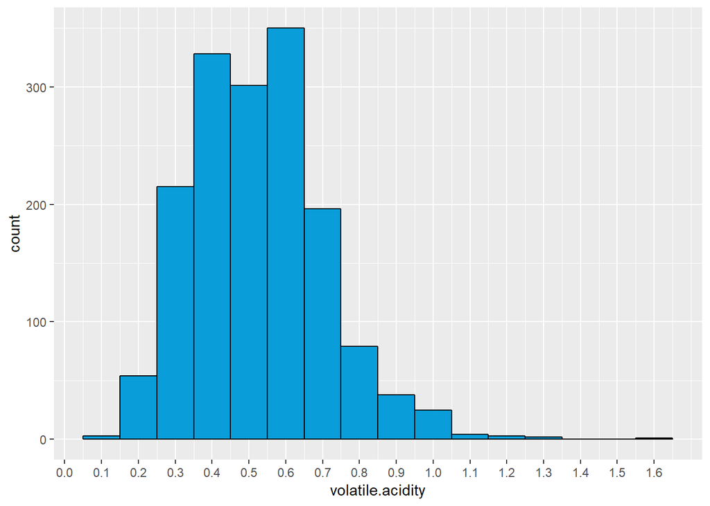

```
##    Min. 1st Qu.  Median    Mean 3rd Qu.    Max.
##   0.000   0.090   0.260   0.271   0.420   1.000
##      nbr.val     nbr.null       nbr.na          min          max
## 1.599000e+03 1.320000e+02 0.000000e+00 0.000000e+00 1.000000e+00
##        range          sum       median         mean      SE.mean
## 1.000000e+00 4.332900e+02 2.600000e-01 2.709756e-01 4.871551e-03
## CI.mean.0.95          var      std.dev     coef.var
## 9.555302e-03 3.794748e-02 1.948011e-01 7.188881e-01
## [1] 63
```

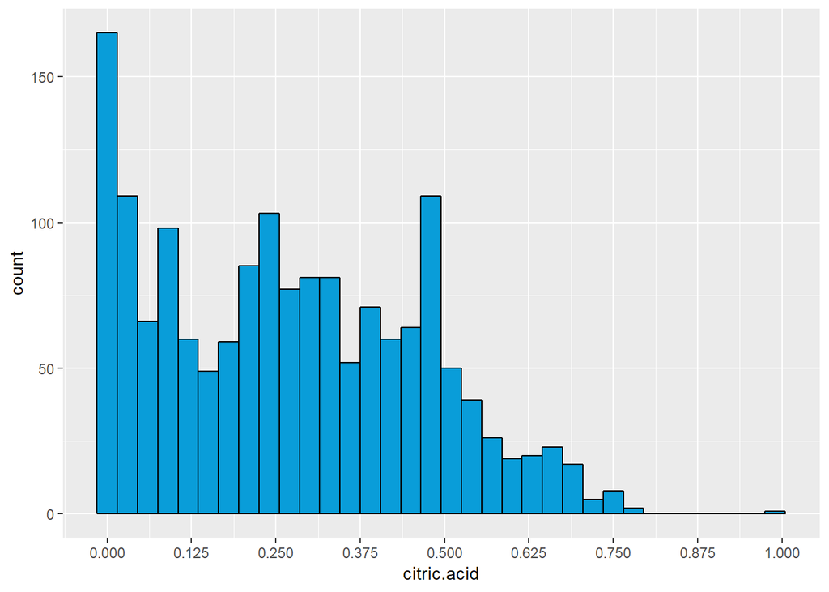

```
##    Min. 1st Qu.  Median    Mean 3rd Qu.    Max.
##   0.900   1.900   2.200   2.539   2.600  15.500
##      nbr.val     nbr.null       nbr.na          min          max
## 1.599000e+03 0.000000e+00 0.000000e+00 9.000000e-01 1.550000e+01
##        range          sum       median         mean      SE.mean
## 1.460000e+01 4.059550e+03 2.200000e+00 2.538806e+00 3.525922e-02
## CI.mean.0.95          var      std.dev     coef.var
## 6.915919e-02 1.987897e+00 1.409928e+00 5.553510e-01
## [1] 50
```

```
## [1] 2.039315
```

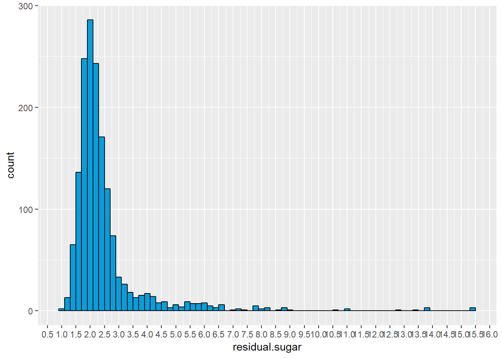

```
##    Min. 1st Qu.  Median    Mean 3rd Qu.    Max.
## 0.01200 0.07000 0.07900 0.08747 0.09000 0.61100
##      nbr.val     nbr.null       nbr.na          min          max
## 1.599000e+03 0.000000e+00 0.000000e+00 1.200000e-02 6.110000e-01
##        range          sum       median         mean      SE.mean
## 5.990000e-01 1.398590e+02 7.900000e-02 8.746654e-02 1.177000e-03
## CI.mean.0.95          var      std.dev     coef.var
## 2.308627e-03 2.215143e-03 4.706530e-02 5.380949e-01
## [1] 63
```

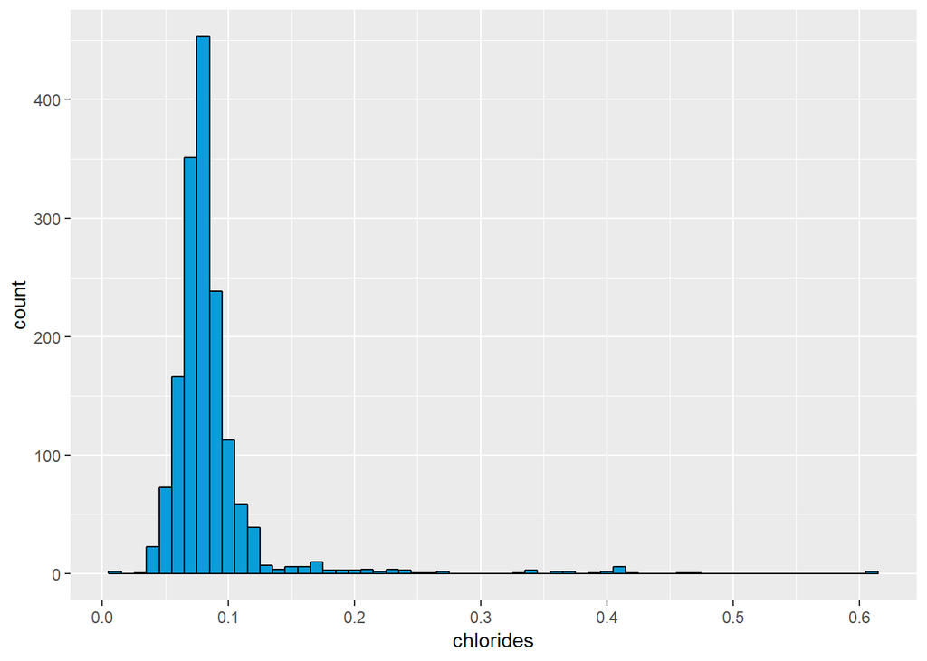

```
##    Min. 1st Qu.  Median    Mean 3rd Qu.    Max.
##    1.00    7.00   14.00   15.87   21.00   72.00
##      nbr.val     nbr.null       nbr.na          min          max
## 1.599000e+03 0.000000e+00 0.000000e+00 1.000000e+00 7.200000e+01
##        range          sum       median         mean      SE.mean
## 7.100000e+01 2.538400e+04 1.400000e+01 1.587492e+01 2.615857e-01
## CI.mean.0.95          var      std.dev     coef.var
## 5.130871e-01 1.094149e+02 1.046016e+01 6.589108e-01
## [1] 74
```

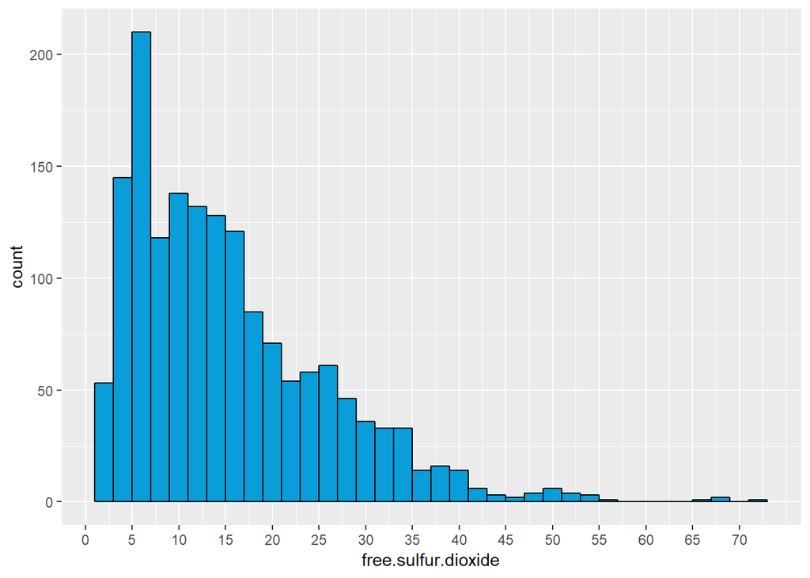

```
##    Min. 1st Qu.  Median    Mean 3rd Qu.    Max.
##    6.00   22.00   38.00   46.47   62.00  289.00
##      nbr.val     nbr.null       nbr.na          min          max
## 1.599000e+03 0.000000e+00 0.000000e+00 6.000000e+00 2.890000e+02
##        range          sum       median         mean      SE.mean
## 2.830000e+02 7.430200e+04 3.800000e+01 4.646779e+01 8.226402e-01
## CI.mean.0.95          var      std.dev     coef.var
## 1.613567e+00 1.082102e+03 3.289532e+01 7.079167e-01
## [1] 55
```

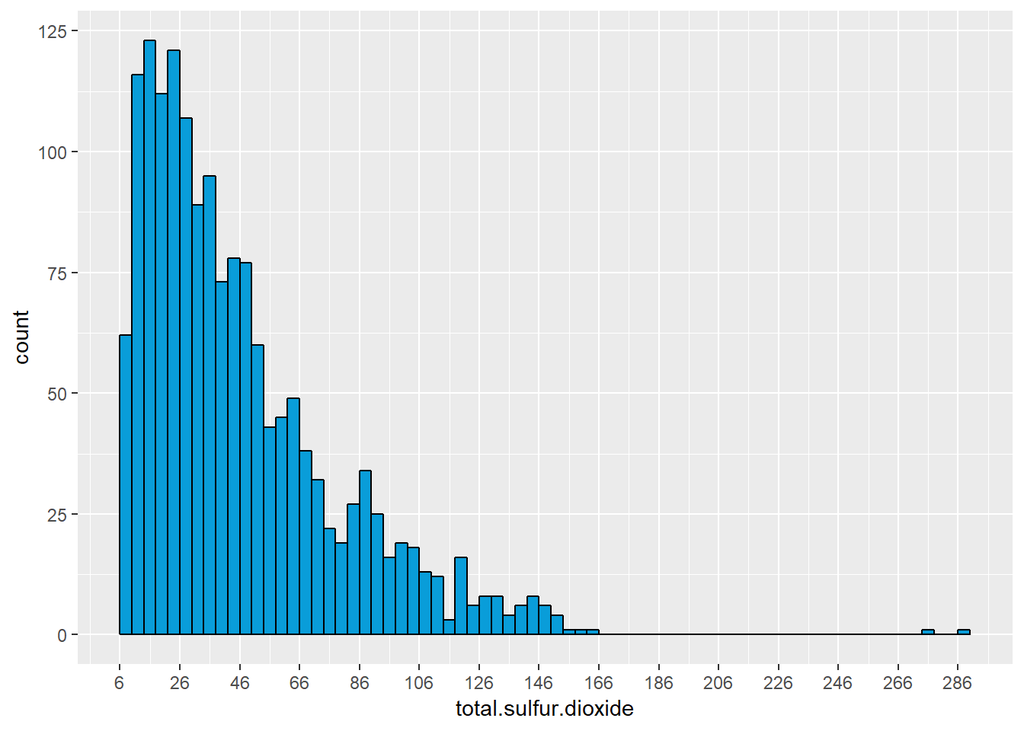

```
##    Min. 1st Qu.  Median    Mean 3rd Qu.    Max.
##  0.9901  0.9956  0.9968  0.9967  0.9978  1.0037
##      nbr.val     nbr.null       nbr.na          min          max
## 1.599000e+03 0.000000e+00 0.000000e+00 9.900700e-01 1.003690e+00
##        range          sum       median         mean      SE.mean
## 1.362000e-02 1.593798e+03 9.967500e-01 9.967467e-01 4.719810e-05
## CI.mean.0.95          var      std.dev     coef.var
## 9.257670e-05 3.562029e-06 1.887334e-03 1.893494e-03
## [1] 253
```

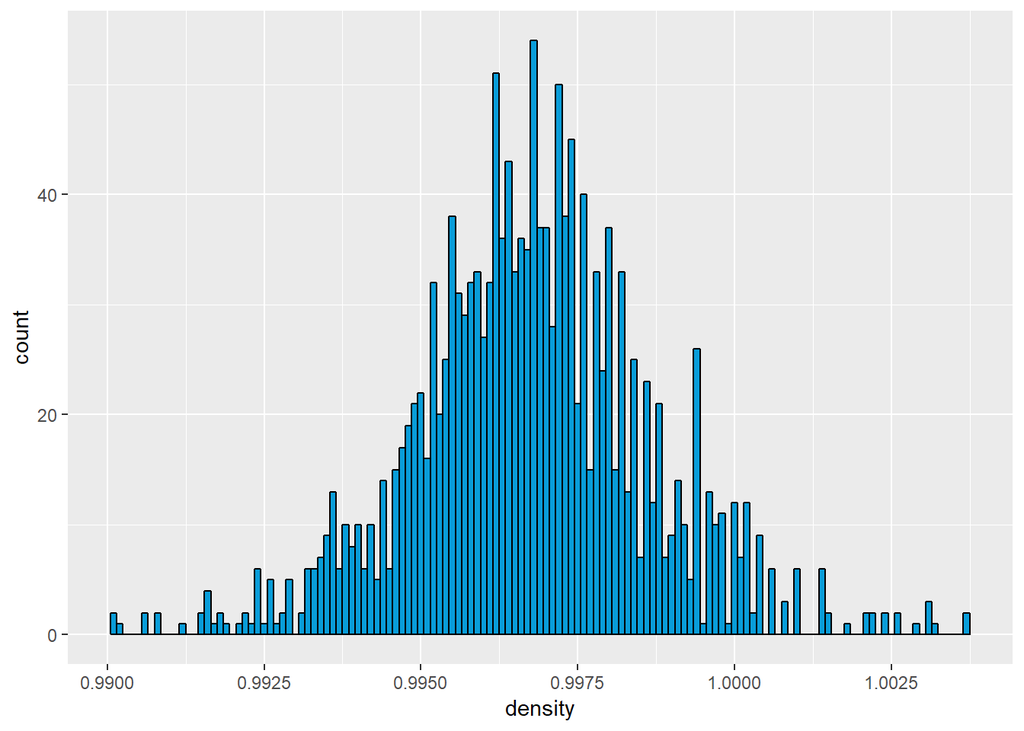

```
##    Min. 1st Qu.  Median    Mean 3rd Qu.    Max.
##   2.740   3.210   3.310   3.311   3.400   4.010
##      nbr.val     nbr.null       nbr.na          min          max
## 1.599000e+03 0.000000e+00 0.000000e+00 2.740000e+00 4.010000e+00
##        range          sum       median         mean      SE.mean
## 1.270000e+00 5.294470e+03 3.310000e+00 3.311113e+00 3.860868e-03
## CI.mean.0.95          var      std.dev     coef.var
## 7.572899e-03 2.383518e-02 1.543865e-01 4.662676e-02
## [1] 235
```

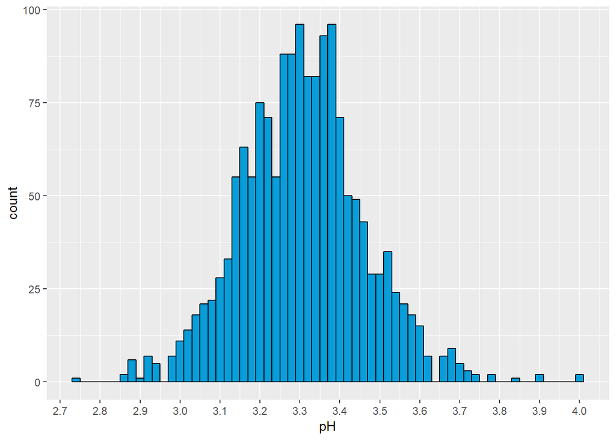

```
##    Min. 1st Qu.  Median    Mean 3rd Qu.    Max.
##  0.3300  0.5500  0.6200  0.6581  0.7300  2.0000
##      nbr.val     nbr.null       nbr.na          min          max
## 1.599000e+03 0.000000e+00 0.000000e+00 3.300000e-01 2.000000e+00
##        range          sum       median         mean      SE.mean
## 1.670000e+00 1.052380e+03 6.200000e-01 6.581488e-01 4.238999e-03
## CI.mean.0.95          var      std.dev     coef.var
## 8.314584e-03 2.873262e-02 1.695070e-01 2.575511e-01
## [1] 93
```

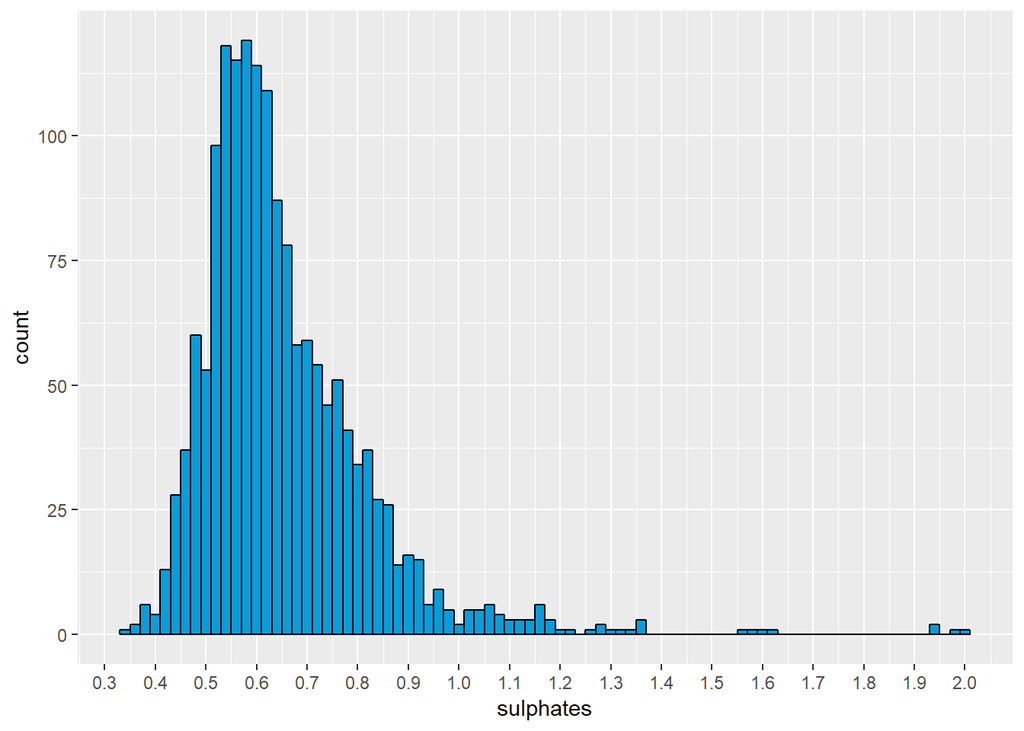

```
##    Min. 1st Qu.  Median    Mean 3rd Qu.    Max.
##    8.40    9.50   10.20   10.42   11.10   14.90
##      nbr.val     nbr.null       nbr.na          min          max
## 1.599000e+03 0.000000e+00 0.000000e+00 8.400000e+00 1.490000e+01
##        range          sum       median         mean      SE.mean
## 6.500000e+00 1.666635e+04 1.020000e+01 1.042298e+01 2.665002e-02
## CI.mean.0.95          var      std.dev     coef.var
## 5.227267e-02 1.135647e+00 1.065668e+00 1.022421e-01
## [1] 116
```

```
## [1] 9.500991
```

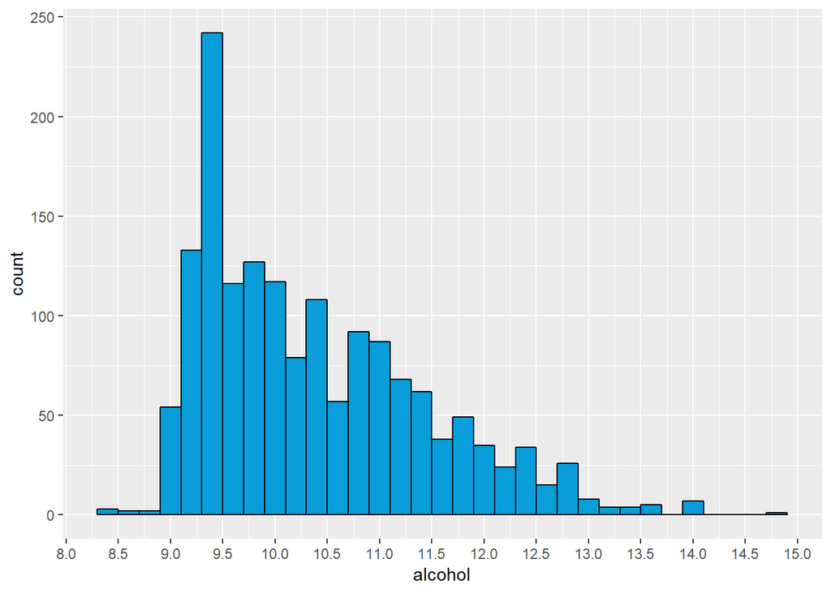

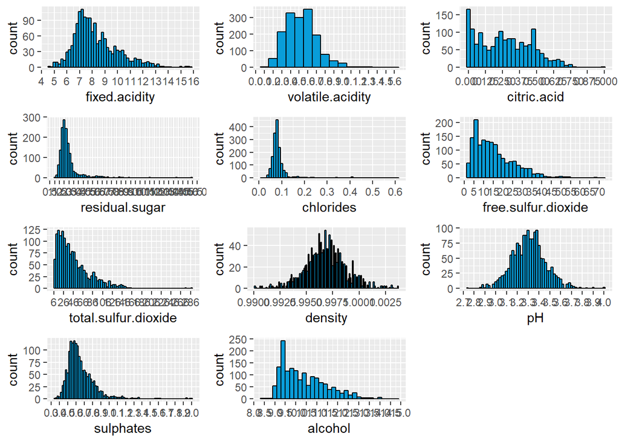

Looking at the graphs, we can see that PH and density have relatively normal distributions, with only a few points deviating drastically from the mean.

The variables with the most drastic outliers seem to be fixed.acidity, residual.sugar, total.sulfur.dioxide, free.sulfur.dioxide and sulphates.

# fixed.acidity:

fixed acidity appears to have a normal distribution around the peak of the data, with some outliers causing a slight tail.

Most wines have a fixed acidity level between 7.10g / dm^3 and 9,20g / dm^3, with a mean of 8.32 g / dm^3.

# volatile.acidity:

there appears to be some outliers, however they do not seem to be affecting the distribution of the data. The distribution is therefore, normal.

# citric.acid:

Most wines have a citric acid between 0.090g / dm^3 and 0.420g / dm^3, with a mean of 0.271 and a median of 0.260.

The data does not appear to be normally distributed. We should note that there are a large number of values that were zero. There does not seem to be an explanation for this, but we can either assume that the actual citric acid of some wines is 09/ dm^3, since “citric acid is found only in very minute quantities in wine grapes” (wikipedia.org), or that they may be input errors.

If we ignore the peaks at zero, there seem to be 2 peaks that stand out: a peak around 0.250 and around 0.500. The graph representing citric acid does not appear to have a shape that can be defines exept for the 2 peaks mentioned above. therefore, we can assume that the distribution of the data may be bimodal.

# residual.sugar:

This histogram may appear to be normally distributed around its peak, however the large numer of outliers cause the data to have a heavily skewed distribution causing a long tail.

Most wines have a risidual sugar range between 1.900 and 2.600, with a Mean of 2.539 and with the largest number of wines having a residual sugar of 2.039.

# chlorides:

Most wines have chlorides ranging between 0.070 and 0.090, with a mean of 0.087. The distribution is long tailed and this is likely due to the number of drastic outliers in the data.

# free.sulfur.dioxide:

The distribution is skewed to the right, with most wines containing free sulfur dioxide between 7mg / dm^3 and 21mg / dm^3. The mean value is 15.87.

Outliers seem to be responsible for the skew in the data.

# total.sulfur.dioxide:

This data is also right-skewed. with wines falling in the range between 22 and 62. there is data that falls in an abnormal range from the rest of the data.

mean is 46.47

# density:

The data appears to be normally distributed, with a mean of 0.996 and with most of the data falling between 0.995 and 0.997

# PH:

# sulphates:

This data appears to be normally distributed at the peak of the data, however, there does appear to be a long tail pulling to the right.

There seem to be some outliers.

Most wines fall between having 0.550 g / dm3 and 0.730 g / dm3 of sulphates, with a mean of 0.658.

# alcohol:

This data is skewed to the right, with a mean of 10.42 and most wines falling between an alcohol content between 9.50 and 11.10.

The largest peak falls around 9.5009, which is considerably higher than most.

# We will take a closer look at outliers and identify those variables that have the most extreme outliers and remove them.

```
## [1] 49
```

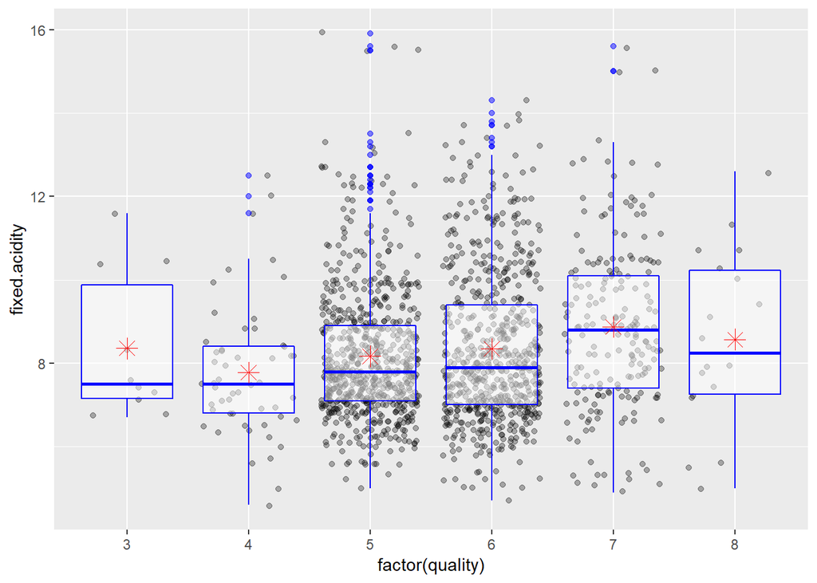

```
## [1] 19
```

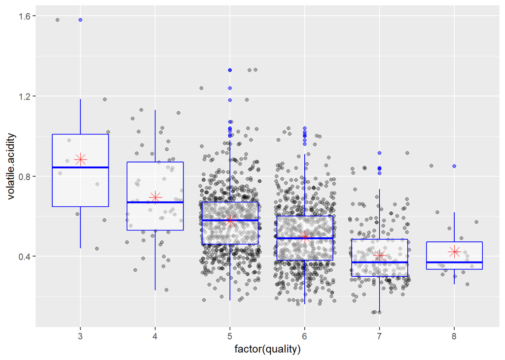

```
## [1] 1
```

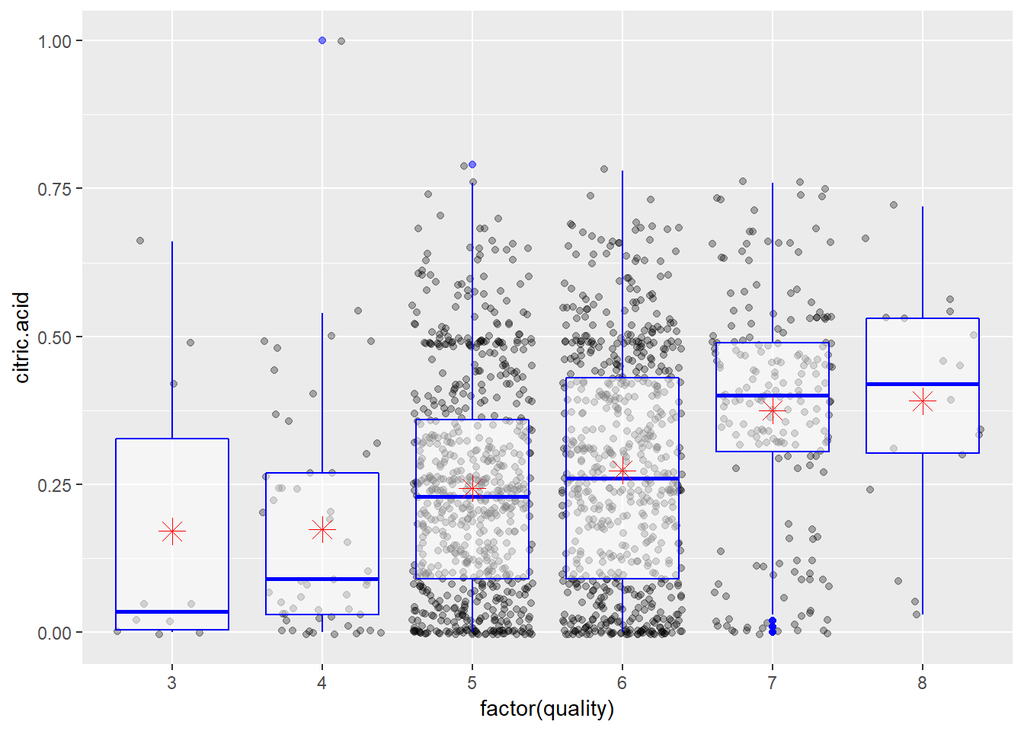

```
## [1] 155
```

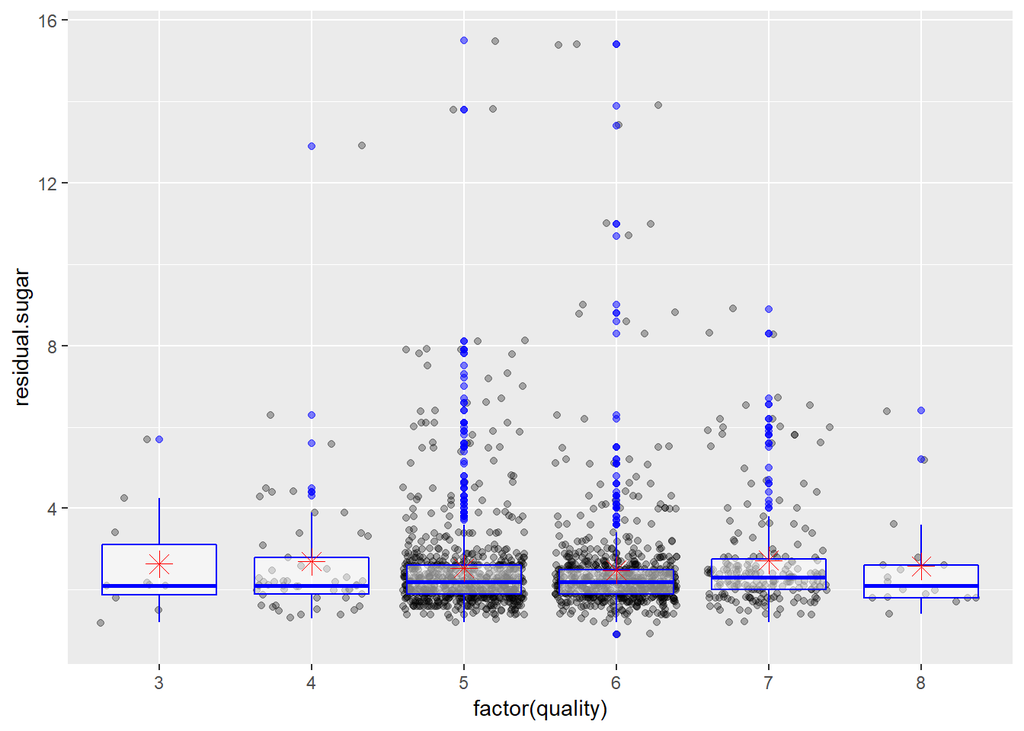

```
## [1] 112
```

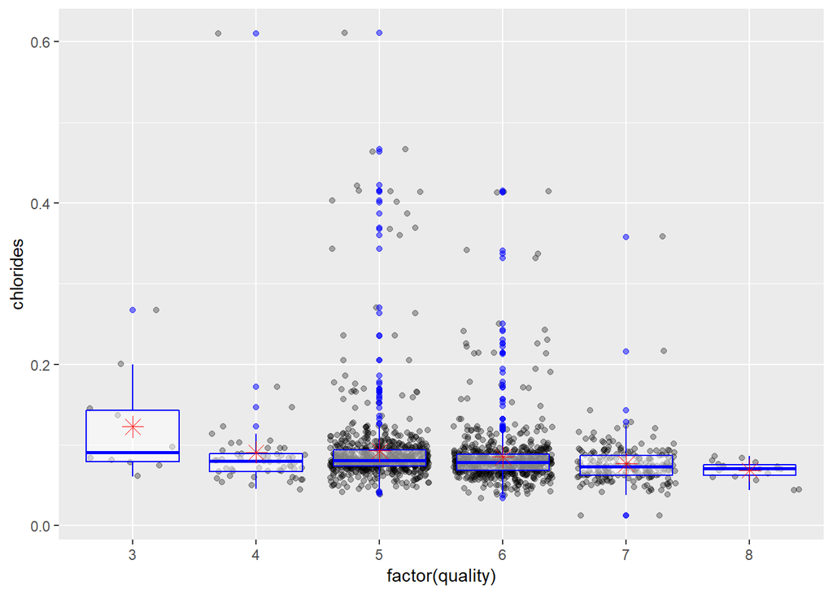

```
## [1] 30
```

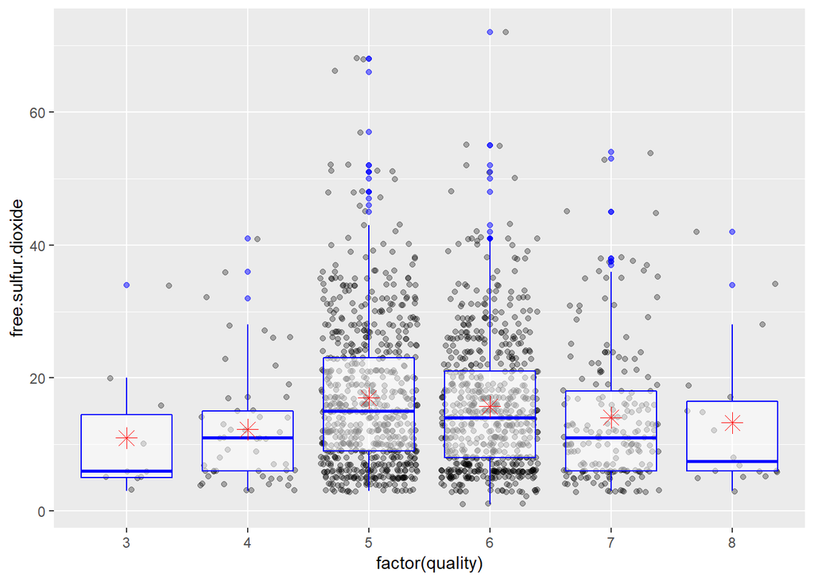

```
## [1] 55
```

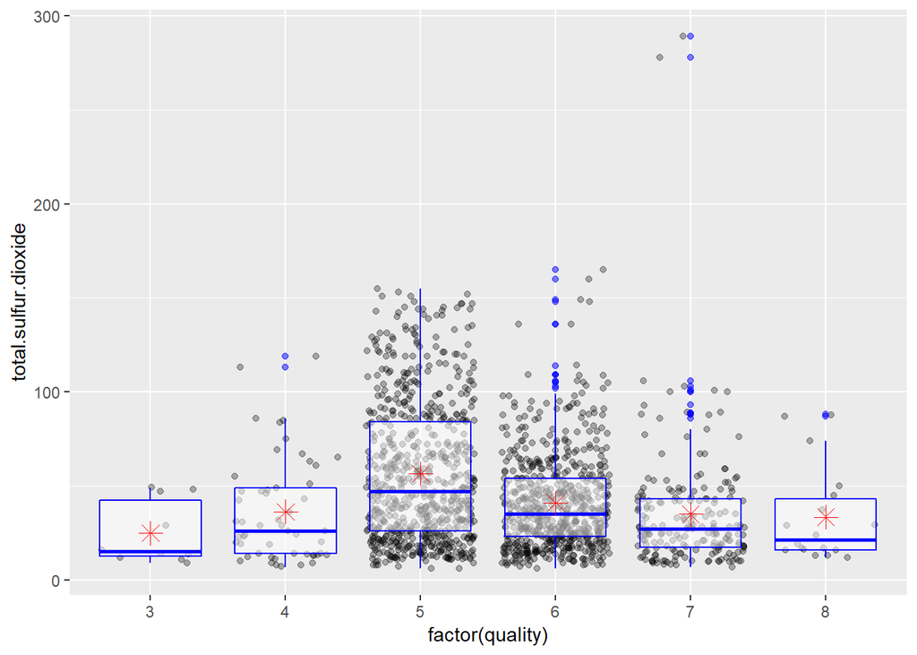

```
## [1] 45
```

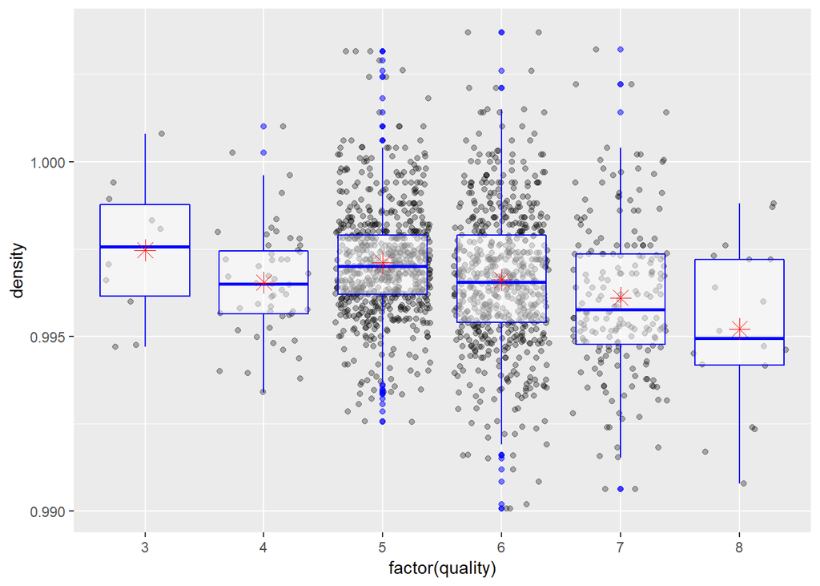

```
## [1] 35
```

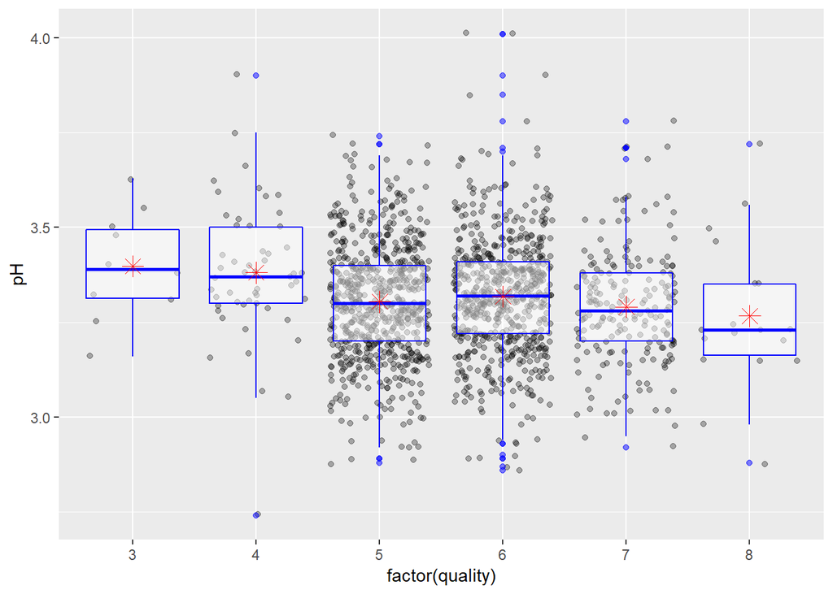

```
## [1] 59
```

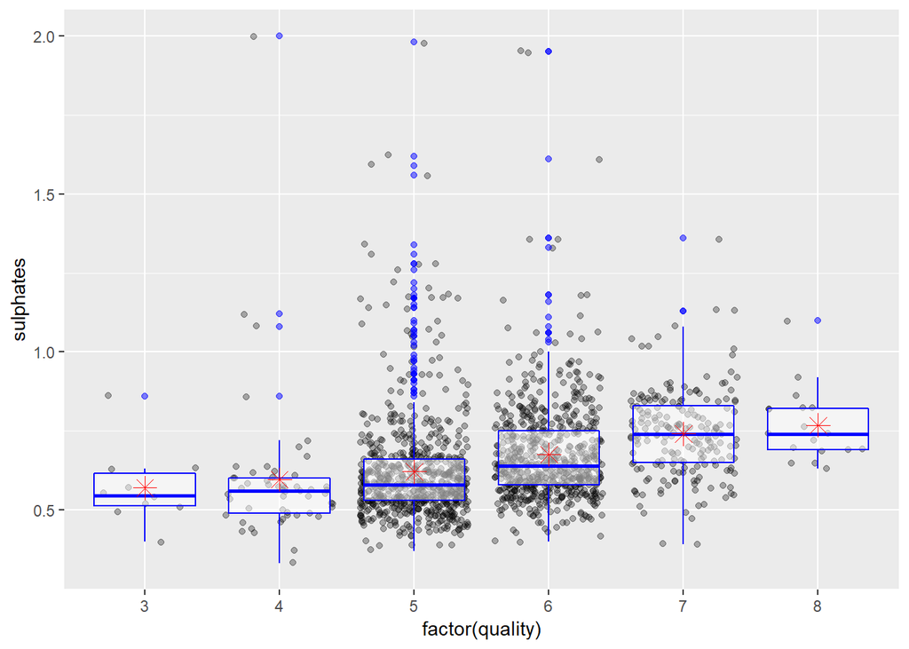

```
## [1] 13
```

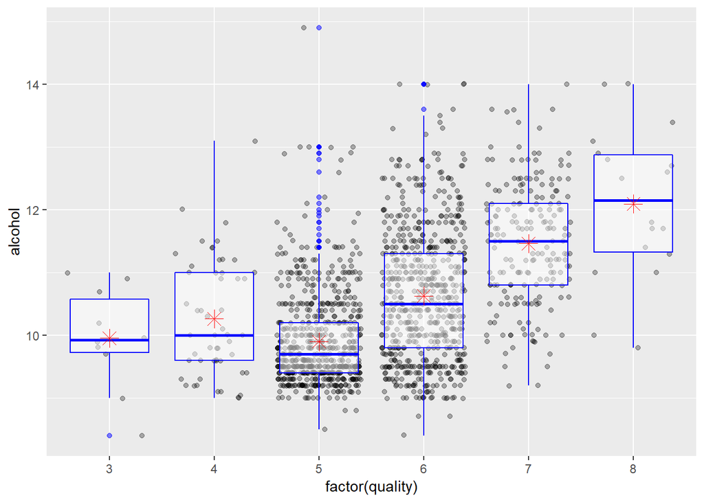

Residual sugar, sulphates, chlorides, fixed acidity, free sulfur dioxide, and total sulfur dioxides appear to have extreme ouliers, which is causing the data to appear long tailed and therefore heavily skewed to the right.

We will look more closely at the variables that seem to have drastic outliers and determine if they do affect the data and distribution and then we will determine wether or not to remove them. If we do remove the outliers, the purpose will be to give the data a normal distribution.

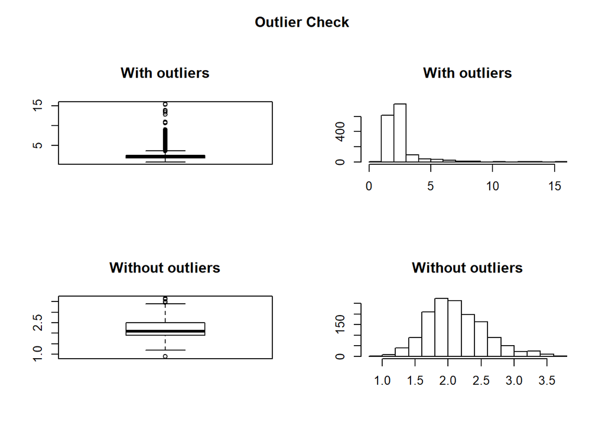

```
## Outliers identified: 155
## Propotion (%) of outliers: 10.7
## Mean of the outliers: 5.88
##  Mean without removing outliers: 2.54
##  Mean if we remove outliers: 2.18
```

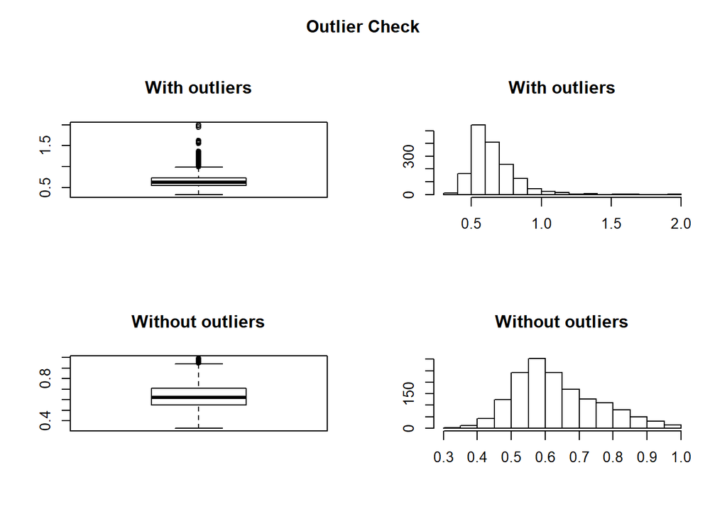

```
## Outliers identified: 59
## Propotion (%) of outliers: 3.8
## Mean of the outliers: 1.23
##  Mean without removing outliers: 0.66
##  Mean if we remove outliers: 0.64
```

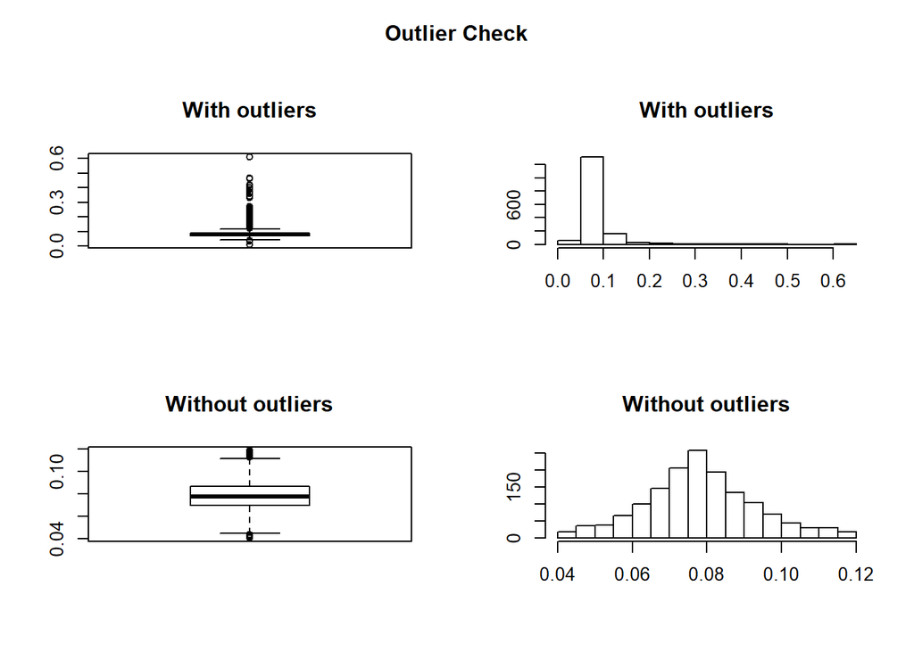

```
## Outliers identified: 112
## Propotion (%) of outliers: 7.5
## Mean of the outliers: 0.2
##  Mean without removing outliers: 0.09
##  Mean if we remove outliers: 0.08
```

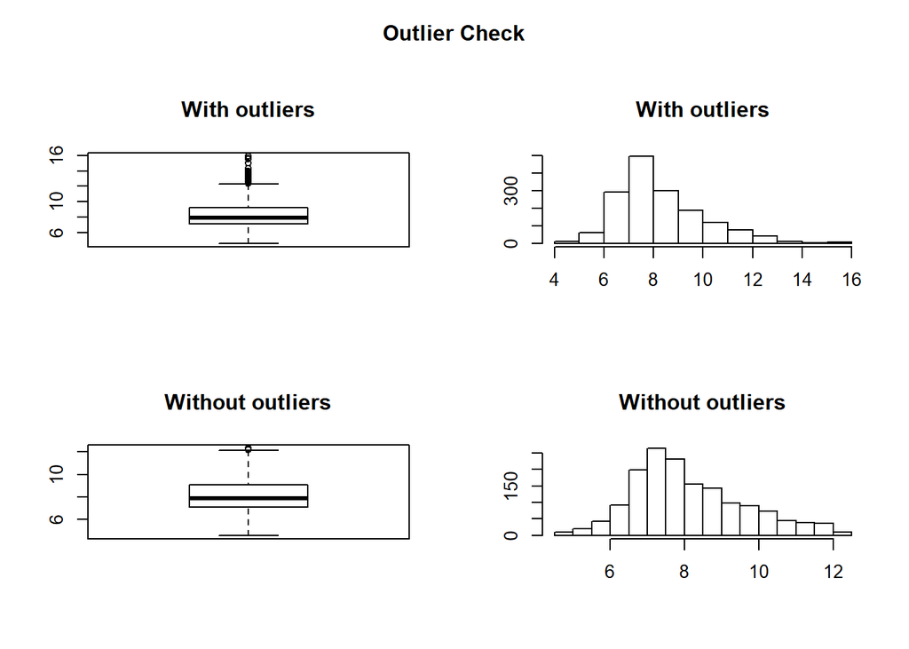

```
## Outliers identified: 49
## Propotion (%) of outliers: 3.2
## Mean of the outliers: 13.29
##  Mean without removing outliers: 8.32
##  Mean if we remove outliers: 8.16
```

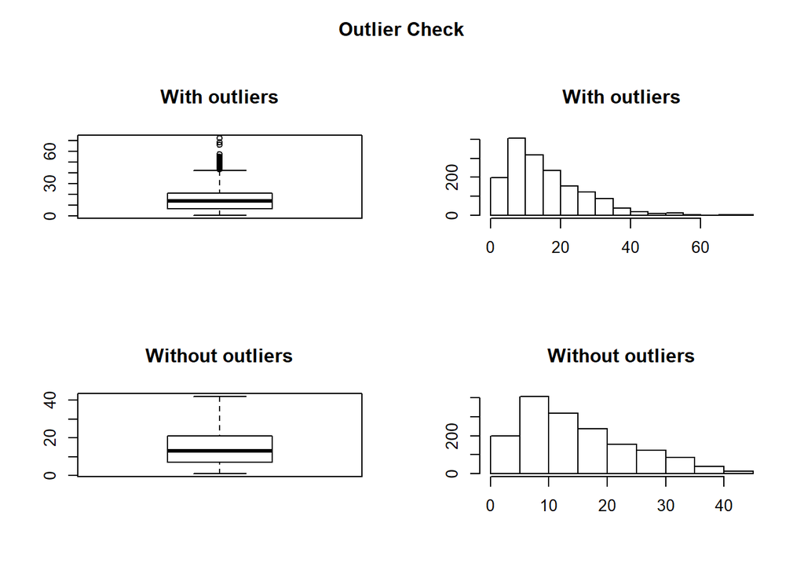

```
## Outliers identified: 30
## Propotion (%) of outliers: 1.9
## Mean of the outliers: 51.9
##  Mean without removing outliers: 15.87
##  Mean if we remove outliers: 15.19
```

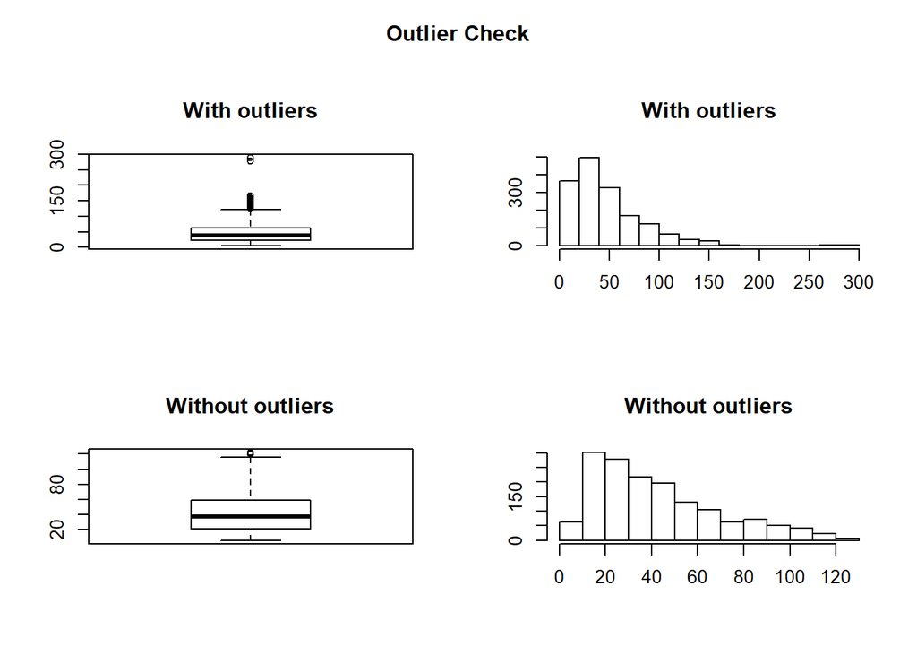

```
## Outliers identified: 55
## Propotion (%) of outliers: 3.6
## Mean of the outliers: 143.89
##  Mean without removing outliers: 46.47
##  Mean if we remove outliers: 43
```

Residual sugar has a total of 155 outliers.

sulphates has a total of 59 outliers.

chlorides has a total of 112 outliers

fixed acidity has a total of 49 outliers.

free sulfur dioxide has a total of 30 outliers

total sulfur dioxide has a total of 55 and will be removed to get rid of the long tail.

# Univariate Analysis

### What is the structure of your dataset?

We initially had 1599 observations in the dataset, we now have 1501 observations because the top 1% of outliers were removed from 6 variables.

Initially we had 13 variables, however the variable x was removed because it appeared to be an index and was not neccessary.

### What is/are the main feature(s) of interest in your dataset?

The main feature of interest is the quality rating of the wines and which of the remaining 11 variables contribute to a decent quality score.

### What other features in the dataset do you think will help support your investigation into your feature(s) of interest?

as above

### Did you create any new variables from existing variables in the dataset?

Only functions

### Of the features you investigated, were there any unusual distributions? Did you perform any operations on the data to tidy, adjust, or change the form of the data? If so, why did you do this?

The only variables which appear to have a normal distribution are quality, pH and density. We removed the outliers from the remaining variables (with most have data that is right-skewed) to create a distribution that is normal.

# Bivariate Plots Section

We will now look at the relationships between quality and variables that may affect a wines quality score. I would assume that alcohol, sweetness, acidity and citric acid would greatly determine wether or not a wine is of good quaility.

I will first explore the relationship between variables using cor() to determine the strength of the relationship and then further explore the correlation visually through plots.

```
##                      fixed.acidity volatile.acidity citric.acid
## fixed.acidity           1.00000000      -0.27616061  0.68955822
## volatile.acidity       -0.27616061       1.00000000 -0.57711617
## citric.acid             0.68955822      -0.57711617  1.00000000
## residual.sugar          0.14302612       0.05576507  0.15502340
## chlorides               0.14881657       0.06886474  0.11085926
## free.sulfur.dioxide    -0.16090289      -0.01945379 -0.07464056
## total.sulfur.dioxide   -0.11266258       0.07783142  0.00531464
## density                 0.65682628       0.02194700  0.35666993
## pH                     -0.70008686       0.25420821 -0.51733534
## sulphates               0.19512399      -0.34899174  0.30631798
## alcohol                -0.06976083      -0.20798800  0.13228883
## quality                 0.12134779      -0.38756817  0.24159999
##                      residual.sugar    chlorides free.sulfur.dioxide
## fixed.acidity            0.14302612  0.148816570         -0.16090289
## volatile.acidity         0.05576507  0.068864735         -0.01945379
## citric.acid              0.15502340  0.110859259         -0.07464056
## residual.sugar           1.00000000  0.071239564          0.03503892
## chlorides                0.07123956  1.000000000         -0.09539368
## free.sulfur.dioxide      0.03503892 -0.095393677          1.00000000
## total.sulfur.dioxide     0.12867046  0.004142243          0.66415552
## density                  0.34059250  0.272344048         -0.06697412
## pH                      -0.06411908 -0.180932981          0.09725710
## sulphates                0.04303161  0.108653406          0.03629582
## alcohol                  0.10290753 -0.209266274         -0.05370715
## quality                  0.02293824 -0.116063023         -0.04171271
##                      total.sulfur.dioxide     density          pH
## fixed.acidity                -0.112662582  0.65682628 -0.70008686
## volatile.acidity              0.077831419  0.02194700  0.25420821
## citric.acid                   0.005314640  0.35666993 -0.51733534
## residual.sugar                0.128670461  0.34059250 -0.06411908
## chlorides                     0.004142243  0.27234405 -0.18093298
## free.sulfur.dioxide           0.664155519 -0.06697412  0.09725710
## total.sulfur.dioxide          1.000000000  0.08792985 -0.01169226
## density                       0.087929854  1.00000000 -0.32338691
## pH                           -0.011692256 -0.32338691  1.00000000
## sulphates                    -0.051989366  0.12418332 -0.04556841
## alcohol                      -0.231644049 -0.51691232  0.19450894
## quality                      -0.198542129 -0.18813595 -0.07447880
##                        sulphates     alcohol     quality
## fixed.acidity         0.19512399 -0.06976083  0.12134779
## volatile.acidity     -0.34899174 -0.20798800 -0.38756817
## citric.acid           0.30631798  0.13228883  0.24159999
## residual.sugar        0.04303161  0.10290753  0.02293824
## chlorides             0.10865341 -0.20926627 -0.11606302
## free.sulfur.dioxide   0.03629582 -0.05370715 -0.04171271
## total.sulfur.dioxide -0.05198937 -0.23164405 -0.19854213
## density               0.12418332 -0.51691232 -0.18813595
## pH                   -0.04556841  0.19450894 -0.07447880
## sulphates             1.00000000  0.22223077  0.38063309
## alcohol               0.22223077  1.00000000  0.48833584
## quality               0.38063309  0.48833584  1.00000000
```

Variables with a positive linear relationship with quality: -Sulphates: 0.38 -Alcohol: 0.49 -Citric acid: 0.24 -Fixed acidity:0.12

Variables with a negative linear relationship with quality: -Volatile acidity: -0.39 -Density: -0.18 -Total sulfur dioxide: -0.19 -Chlorides: -0.11